# AFDMD-111 Estadística

Lectura de archivos en R

Crisanta Cruz Vazquez

20/09/2023

# Lectura de archivos en R

`R` puede leer una gran cantidad de archivos incluyendo archivos `.txt`, `.csv`, `.xls`, `.pdf`, etc. Mediante el uso del paquete `tabulizer` se pueden leer tablas que se encuentran en documentos `PDF`. En la siguiente actividad se instalará y cargará el paquete `tabulizer` mediante los comandos:

```r
install.packages("tabulizer", dependencies = TRUE)   # Instala tabulizer
library(tabulizer)                                   # Carga tabulizer
```

Posteriormente se leerá la tabla localizada en el archivo `seccion_calificacionesmsosa247.pdf` que se encuentra en la sección de **archivos** del *Teams* (lo anterior se puede hacer mediante el comando `extract_tables` del tabulizer). Una vez cargada la tabla que se llamará `tablaAlumnos` se realizarán las siguientes actividades:

### 1.- Graficar `No` contra `Parcial 1`.

```r
library(tabulizer)
tap<-extract_tables("seccion_calificacionesmsosa247.pdf", output = "data.frame")
tap<- tap[[1]]
names(tap)
```

```
[1] "No"        "Matricula" "Nombre"    "Parcial"   "Parcial.1" "Ev."
[7] "Calif."
```

```r
names(tap)<-c("No","Matricula","Nombre", "parcial1","parcial2","parcial3", "promedio")
head(tap)
```

```
  No Matricula                          Nombre parcial1 parcial2 parcial3
1  1 150300135       ALEJO ALEJANDRO / MIJARES        8        7        7
2  2 150300161       CAN BACAB / HECTOR ARTURO       10        8        8
3  3 150300087      CAN BACAB / SERGIO ANTONIO        7        8        9
4  4 140300086 CERVANTES VILLEGAS / ALAN JAIME        0        0        0
5  5 150300109    CONSTANTINO ISNEROS / MOISES        9        9        6
6  6 150300170          CORONA MERCADO / JESUS        7        6        5
  promedio
1        7
2        9
3        8
4        0
5        8
6        6
```

```r
names(tap)
```

```
[1] "No"        "Matricula" "Nombre"    "parcial1"  "parcial2"  "parcial3"
[7] "promedio"
```

```r
tap$parcial1
```

```
 [1]  8 10  7  0  9  7  8  7  8  8  5  8  6  8  8  4  8  7  7  5  3  8  6  9
```

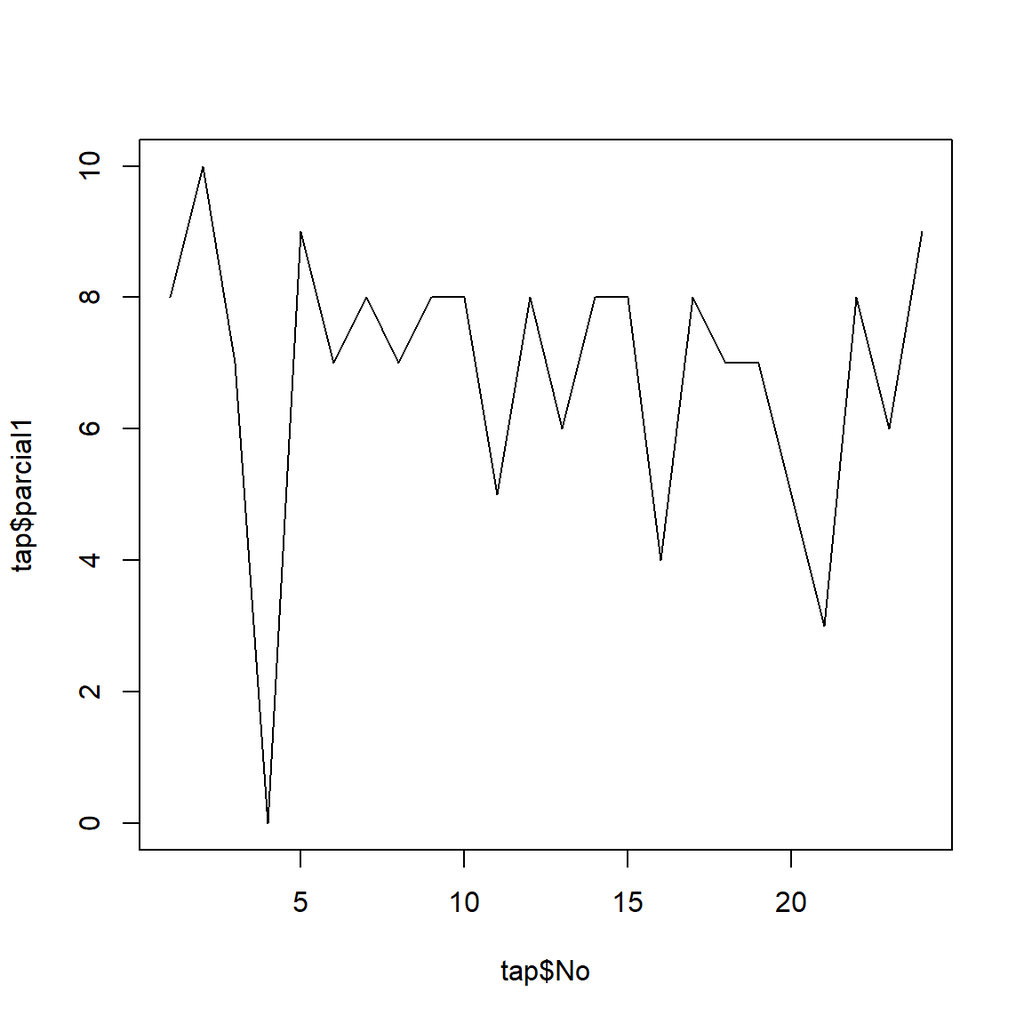

```r
plot(tap$No,tap$parcial1,type = "l")
```

### 2.- Graficar `No` contra `Parcial 2`.

```r
library(tabulizer)
tap<-extract_tables("seccion_calificacionesmsosa247.pdf", output = "data.frame")
tap<- tap[[1]]
names(tap)
```

```
[1] "No"        "Matricula" "Nombre"    "Parcial"   "Parcial.1" "Ev."
[7] "Calif."
```

```r
names(tap)<-c("No","Matricula","Nombre", "parcial1","parcial2","parcial3", "promedio")
head(tap)
```

```
  No Matricula                          Nombre parcial1 parcial2 parcial3
1  1 150300135       ALEJO ALEJANDRO / MIJARES        8        7        7
2  2 150300161       CAN BACAB / HECTOR ARTURO       10        8        8
3  3 150300087      CAN BACAB / SERGIO ANTONIO        7        8        9
4  4 140300086 CERVANTES VILLEGAS / ALAN JAIME        0        0        0
5  5 150300109    CONSTANTINO ISNEROS / MOISES        9        9        6
6  6 150300170          CORONA MERCADO / JESUS        7        6        5
  promedio
1        7
2        9
3        8
4        0
5        8
6        6
```

```r
names(tap)
```

```
[1] "No"        "Matricula" "Nombre"    "parcial1"  "parcial2"  "parcial3"
[7] "promedio"
```

```r
tap$parcial1
```

```
 [1]  8 10  7  0  9  7  8  7  8  8  5  8  6  8  8  4  8  7  7  5  3  8  6  9
```

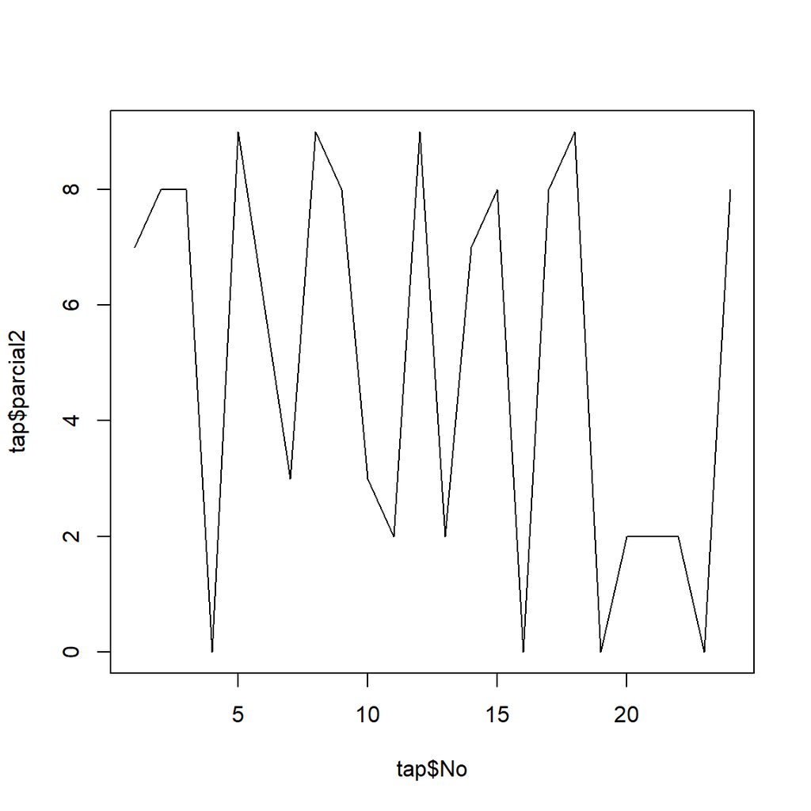

```r
plot(tap$No,tap$parcial2,type = "l")
```

### 3.- Renombrar `Ev.` a `Parcial 3` (mostrar el `data.frame` resultante).

```r
library(tabulizer)
tap<-extract_tables("seccion_calificacionesmsosa247.pdf", output = "data.frame")
tap<- tap[[1]]
names(tap)
```

```
[1] "No"        "Matricula" "Nombre"    "Parcial"   "Parcial.1" "Ev."
[7] "Calif."
```

```r
names(tap)<-c("No","Matricula","Nombre", "parcial1","parcial2","parcial3", "promedio")
head(tap)
```

```
  No Matricula                          Nombre parcial1 parcial2 parcial3
1  1 150300135       ALEJO ALEJANDRO / MIJARES        8        7        7
2  2 150300161       CAN BACAB / HECTOR ARTURO       10        8        8
3  3 150300087      CAN BACAB / SERGIO ANTONIO        7        8        9
4  4 140300086 CERVANTES VILLEGAS / ALAN JAIME        0        0        0
5  5 150300109    CONSTANTINO ISNEROS / MOISES        9        9        6
6  6 150300170          CORONA MERCADO / JESUS        7        6        5
  promedio
1        7
2        9
3        8
4        0
5        8
6        6
```

```r
names(tap)
```

```
[1] "No"        "Matricula" "Nombre"    "parcial1"  "parcial2"  "parcial3"
[7] "promedio"
```

```r
tap$parcial3
```

```
 [1]  7  8  9  0  6  5 10  6  8 10  5  9 10  6  8  0  6  9  7  9  0 10  0  4
```

### 4.- Graficar `No` contra `Parcial 1`, `Parcial 2`.

```r
library(tabulizer)
tap<-extract_tables("seccion_calificacionesmsosa247.pdf", output = "data.frame")
tap<- tap[[1]]
names(tap)
```

```
[1] "No"        "Matricula" "Nombre"    "Parcial"   "Parcial.1" "Ev."
[7] "Calif."
```

```r
names(tap)<-c("No","Matricula","Nombre", "parcial1","parcial2","parcial3", "promedio")
head(tap)
```

```
  No Matricula                          Nombre parcial1 parcial2 parcial3
1  1 150300135       ALEJO ALEJANDRO / MIJARES        8        7        7
2  2 150300161       CAN BACAB / HECTOR ARTURO       10        8        8
3  3 150300087      CAN BACAB / SERGIO ANTONIO        7        8        9
4  4 140300086 CERVANTES VILLEGAS / ALAN JAIME        0        0        0
5  5 150300109    CONSTANTINO ISNEROS / MOISES        9        9        6
6  6 150300170          CORONA MERCADO / JESUS        7        6        5
  promedio
1        7
2        9
3        8
4        0
5        8
6        6
```

```r
names(tap)
```

```
[1] "No"        "Matricula" "Nombre"    "parcial1"  "parcial2"  "parcial3"
[7] "promedio"
```

```r
str(tap$parcial1)
```

```
 int [1:24] 8 10 7 0 9 7 8 7 8 8 ...
```

```r
str(tap$parcial2)
```

```
 int [1:24] 7 8 8 0 9 6 3 9 8 3 ...
```

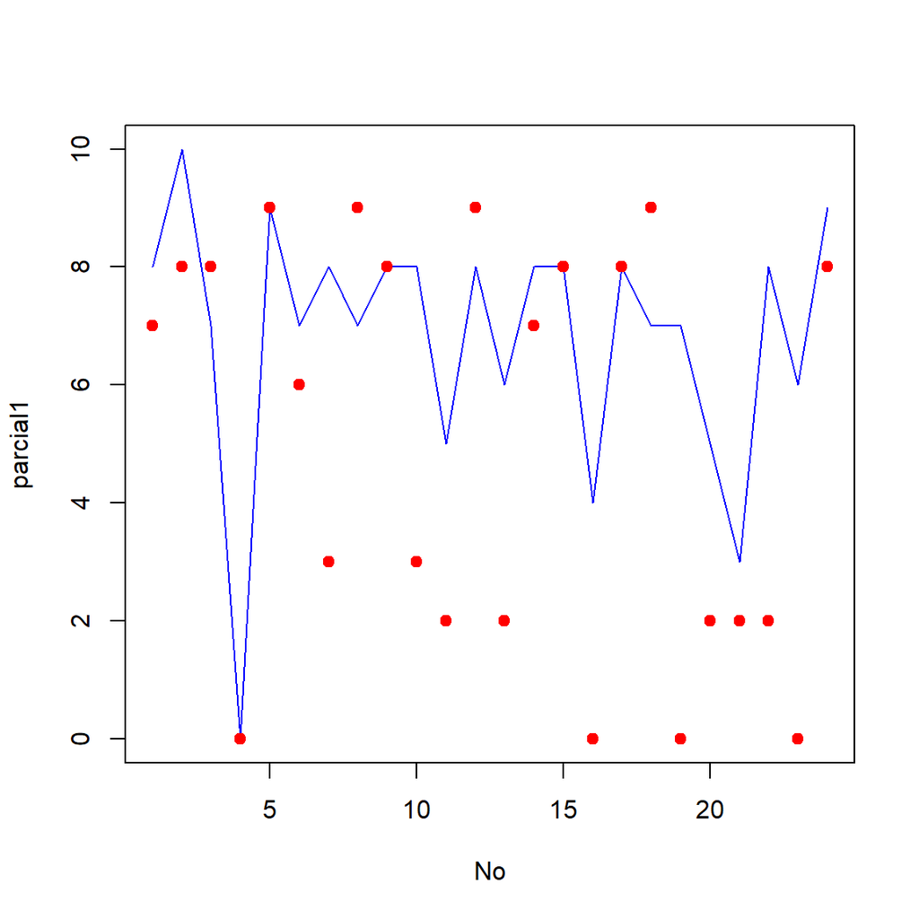

```r
plot(tap$No,tap$parcial1,type = "l",col = "blue", xlab = "No", ylab = "parcial1")
points(tap$No,tap$parcial2, col = "red", pch = 19)
```

### 5.- ¿Cuál es la media de las calificaciones finales? ¿Quién obtuvo la calificación más baja? ¿Quién obtuvo el mejor promedio? (anexar el código que lo calcula).

```r
library(tabulizer)
tap<-extract_tables("seccion_calificacionesmsosa247.pdf", output = "data.frame")
tap<- tap[[1]]
names(tap)
```

```
[1] "No"        "Matricula" "Nombre"    "Parcial"   "Parcial.1" "Ev."
[7] "Calif."
```

```r
head(tap)
```

```
  No Matricula                          Nombre Parcial Parcial.1 Ev. Calif.
1  1 150300135       ALEJO ALEJANDRO / MIJARES       8         7   7      7
2  2 150300161       CAN BACAB / HECTOR ARTURO      10         8   8      9
3  3 150300087      CAN BACAB / SERGIO ANTONIO       7         8   9      8
4  4 140300086 CERVANTES VILLEGAS / ALAN JAIME       0         0   0      0
5  5 150300109    CONSTANTINO ISNEROS / MOISES       9         9   6      8
6  6 150300170          CORONA MERCADO / JESUS       7         6   5      6
```

```r
names(tap)<-c("No","Matricula","Nombre", "parcial1","parcial2","parcial3", "promedio")
promedio_general <- mean(tap$promedio)
cat("Media de las calificaciones finales:", promedio_general, "\n")
```

```
Media de las calificaciones finales: 5.958333
```

```r
estudiante_calificacion_mas_baja <- tap[which.min(tap$promedio), ]
cat("Estudiante con la calificación más baja:\n")
```

```
Estudiante con la calificación más baja:
```

```r
cat("=====================================\n")
print(estudiante_calificacion_mas_baja)
```

```
  No Matricula                          Nombre parcial1 parcial2 parcial3
4  4 140300086 CERVANTES VILLEGAS / ALAN JAIME        0        0        0
  promedio
4        0
```

```r
cat("\n")
```

```r
estudiante_mejor_promedio <- tap[which.max(tap$promedio), ]
cat("Estudiante con el mejor promedio:\n")
```

```
Estudiante con el mejor promedio:
```

```r
cat("====================================\n")
print(estudiante_mejor_promedio)
```

```
  No Matricula                    Nombre parcial1 parcial2 parcial3 promedio
2  2 150300161 CAN BACAB / HECTOR ARTURO       10        8        8        9
```

```r
if (!requireNamespace("dplyr", quietly = TRUE)) {
  install.packages("dplyr")
}


library(dplyr)
library(tabulizer)
tap<-extract_tables("seccion_calificacionesmsosa247.pdf", output = "data.frame")
tap<- tap[[1]]
names(tap)<-c("No","Matricula","Nombre", "parcial1","parcial2","parcial3", "promedio")
tap <- tap %>%
  mutate(across(starts_with("parcial"), as.numeric))
tap <- tap %>%
  mutate(promedio = rowMeans(select(., starts_with("parcial")), na.rm = TRUE))
head(tap)
```

```
  No Matricula                          Nombre parcial1 parcial2 parcial3
1  1 150300135       ALEJO ALEJANDRO / MIJARES        8        7        7
2  2 150300161       CAN BACAB / HECTOR ARTURO       10        8        8
3  3 150300087      CAN BACAB / SERGIO ANTONIO        7        8        9
4  4 140300086 CERVANTES VILLEGAS / ALAN JAIME        0        0        0
5  5 150300109    CONSTANTINO ISNEROS / MOISES        9        9        6
6  6 150300170          CORONA MERCADO / JESUS        7        6        5
  promedio
1 7.333333
2 8.666667
3 8.000000
4 0.000000
5 8.000000
6 6.000000
```